# Exploring Advantages of Using TopPIC for Top-down MS Proteomics through Ovarian Cancer Data

Zhige (Daniel) Wang

[Link to website](https://todanielwang.github.io/projects/datascience/milestone2.html)

## Project Goals

As the title suggests, the goal of this project is to use the public ovarian cancer dataset, a set of data that's well-regarded as good Top-down MS-based raw data, and use TopPIC, a tool created and maintained by our own lab, to do the general pipeline of workflow and analysis said raw data and lastly obtaining a list of proteoform identifications. Similar with all other available tools, TopPIC will have it's pros and cons as to the type of raw data it can identify the most, and so this project aims to explore what exactly those pros and cons are in comparsion to other major tools such as MSPathFinder or ProSight. Since ProSight requires a lisence, this project will focus on comparsions with MSPathFinder.

## Project Background

This project deals with the minor field of Top-down MS-based proteomics, but its core is still about the performance of a certain analytical tool, hence very little biological knowledge is required to understand the meaningfulness of this project. Dispite that, I still need to explain a little more on this field and what exactly TopPIC does. The computer science/informatics side of modern-day proteomics is inherently about protein and proteoform (different variations of the same protein) identification. That is to say, given a sample of proteins, we need to figure out what this sample consists of, more specifically, what's the amino acid sequence of the proteins in the sample.

Top-down MS-based proteomics is one approach to this problem, that we take advantage of a machinery known as the mass spectrometry (MS), which is an analytical technique that is used to measure the mass-to-charge(m/z) ratio of ions. These m/z ratios would allow us to uniquely identify proteins/proteoforms using database search. But of course, in practice, the unique condition becomes a little rusty as noise and imprecision of the machinery comes into play while having to deal with huge computational complexity of searching through a database in terms of millions. And hence advance computational tools such as TopPIC were introduced to deal with these problems, that it would take the raw data generated by (MS), and return a set of protein/proteoform identifications.

Now there are essentially two things that defines a spectrum (unit of raw data), and impacts the database search. The MS1 feature, also known as precursor feature, and MS2 fragments, also known as peak list. Explaining why they act the way they are will dive into deep biology, so I will directly explain how they impact each other. The list of possbile precursor features needs to be first identified through a process known as feature detection, which is handled by TopFD, a part of the the TopPIC Suite. Then each spectra need to be manually assigned a precursor feature, which includes precursor mass, precursor charge, and adjusted precursor m/z. Identifiying the full list of precurosr and properly assign them to the spectra is crucial that they also play a part in identifying the list of peaks, which is what's searched against the database.

The process mentioned above is also being conducted through the MSPathFinder package as well, that they use ProMex for feature detection and MSPathFinderT for database search. One needs to note the difference in default input parameters, that it's very important to use the same set of parameters even though some might not be directly supported by the tools.

## Project Datasets

This dataset can be found at MassIVE using the unique identifier MSV000080257 or accessed through this [link](https://massive.ucsd.edu/ProteoSAFe/dataset.jsp?task=d95d54a09d894022b033f3fc058ee95b). Do note that the datasets cannot be direclty downloaded through the browser, but through a FTP. And of course, this is 20 GB of public data for which is too much data to do a total analysis on, so we focus on a randomly chosen file labeled as CPTAC_Intact_rep1_15Jan15_Bane_C2-14-08-02RZ. And again, since this data is the raw data produced by the MS, we must run it through the Top-down search pipeline first to obtain data we need.

We will first run the raw dataset through a tool called MSConvert, which converts the raw data into a generally accepted format known as mzML, which is raw data parsed into xml with certain places compressed into hexadecimal incodings. We will then do feature detection using TopFD, a part of the TopPIC Suite, which would output us ms1.feature, ms2.feature, and ms2.align files. The first two files are tsv files under the hood which we will be looking at the first file. The last file is a txt file with certain structure that we standardized for database search. These three files will then be used as input to TopPIC, which performs the database search against a .fasta file downloaded from UniProt, and will output many different result files, and we are particularly interested in prsm_single.tsv.

Out of this process, there are two files that we will be looking at with close attetion. Namely ms1.feature, and prsm_single.tsv. As mentioned before, it's very important that we are assigning the correct precursor feature to each spectra, that a wrongly assigned precursor will likely to cause a difference in the peak list, but also possibly provide the wrong identification. Hence we must be looking at both the identification results and the list of features.

A similar process will happen using MSPathFinder as well, that we need to use the format of mzML to pass into PBFGen, a preprocessing tool as a part of the MSPathFinder package. This will return a output file with extension .pbf, which is custum file format acceptable by the rest of the package. It would then be thrown into ProMex with settings that sets the parameters the same as the default parameters of TopFD. Note that ProMex talks about minimum mass and minimum charge that's not part of the parameters of TopFD, but these two parameters are very unlikely to have an effect on the result as the internal default minimum charge is just 1, and the minimum mass varies based on the intensity of spectrum through a noise-signal ratio, which is a better filter than having a minimum mass directly being set. Now ProMex will output .ms1ft, which is the counterpart to ms1.feature files generated by TopFD. And lastly using both .ms1ft and .pbf as inputs, we can run MSPathFinderT against the same .fasta database, for which it would output _IcTarget.tsv, a counterpart to prsm_single.tsv. We see similar problems in MSPathFinder as well that it contains parameters not mentioned by TopPIC, yet they do not possess a real threat similar with reasons before.

Some of questions we will be answering through the project is: what type of spectra, or more specifically, what range of precursor are we more likely to identify and assign correctly using TopPIC in comparsion to MSPathFinder. Is there a preference in precursur mass, that perhaps higher precursur mass would more likely result in an protein identification? What type of spectra are TopPIC missing in comparsion with MSPathFinder and is there a trend as to the ones that we missed.

## ETL (Extraction, Transform, and Load)

There will not be much ETL happening with TopPIC as all data are generated using analytical tools we developed, though I will drop a couple columns that's not very useful for me. And prsm_single.tsv does indeed have a header, which are the parameters for the tool, that which I removed so that it can properly read by pandas as a tsv. In addition, I loaded the .ms1ft and _IcTarget.tsv outputed by MSPathFinder as well, and in order to do proper comparsions I need to first do some preprocessing with that so things come in the same format.

```python
import pandas as pd
from matplotlib import pyplot as plt
import numpy as np

#importing ms1 features and dropping useless columns
ms1_feature_TopPIC = pd.read_csv("./data/TopPIC/CPTAC_Intact_rep1_15Jan15_Bane_C2-14-08-02RZ_ms1.feature", delimiter="\t", index_col="ID")
ms1_feature_TopPIC.drop(columns=["Sample_ID", "Minimum_fraction_id", "Maximum_fraction_id"], inplace=True)
display(ms1_feature_TopPIC.head())
display(ms1_feature_TopPIC.dtypes)


#importing result prsm_single.tsv and dropping useless columns
prsm_df_TopPIC = pd.read_csv("./data/TopPIC/CPTAC_Intact_rep1_15Jan15_Bane_C2-14-08-02RZ_ms2_toppic_prsm_single.tsv", delimiter="\t", index_col="Prsm ID")
prsm_df_TopPIC.drop(columns=["Data file name", "Spectrum-level Q-value", "Proteoform-level Q-value", "Fragmentation", "MIScore", "Spectrum ID", "Protein description"], inplace=True)
display(prsm_df_TopPIC.head())
display(prsm_df_TopPIC.dtypes)

#importing ms1ft and dropping useless columns
ms1_feature_MSP = pd.read_csv("./data/MSPathFinder/CPTAC_Intact_rep1_15Jan15_Bane_C2-14-08-02RZ_ms1ft.csv", delimiter=",")
ms1_feature_MSP.drop(columns=["fit", "monoisotopic_mw"], inplace=True)
#It's better to also have a mass column
ms1_feature_MSP["Mass"] = ms1_feature_MSP["charge"] * ms1_feature_MSP["mz"]
display(ms1_feature_MSP.head())
display(ms1_feature_MSP.dtypes)

#Getting the search result from _IcTarget.tsv and change their format
prsm_df_MSP = pd.read_csv("./data/MSPathFinder/CPTAC_Intact_rep1_15Jan15_Bane_C2-14-08-02RZ_IcTarget.tsv", delimiter="\t")
prsm_df_MSP["Pre"].replace("-", "", inplace=True)
prsm_df_MSP["Post"].replace("-", "", inplace=True)
prsm_df_MSP["Proteoform"] = prsm_df_MSP[['Pre', 'Sequence', 'Post']].agg('.'.join, axis=1)
prsm_df_MSP.drop(columns=["Composition", "ProteinDesc", "Pre", "Post"], inplace=True)
display(prsm_df_MSP.head())
display(prsm_df_MSP.dtypes)
```

| ID | Mass | Intensity | Time_begin | Time_end | Apex_time | Apex_intensity | Minimum_charge_state | Maximum_charge_state |
| --- | --- | --- | --- | --- | --- | --- | --- | --- |
| 0 | 2883.627925 | 3.327920e+09 | 5522.36 | 6150.23 | 5558.36 | 3.772398e+08 | 3 | 7 |
| 1 | 4960.498156 | 3.321628e+09 | 4258.23 | 4702.81 | 4294.94 | 3.303075e+08 | 3 | 9 |
| 2 | 3640.970182 | 3.718496e+09 | 8917.85 | 9245.73 | 8960.28 | 3.051384e+08 | 2 | 7 |
| 3 | 2884.621125 | 3.006718e+08 | 5522.36 | 5567.46 | 5567.46 | 3.005344e+08 | 5 | 6 |
| 4 | 4958.519580 | 2.883442e+08 | 4302.92 | 4302.92 | 4302.92 | 2.883442e+08 | 6 | 6 |

```
Mass                    float64
Intensity               float64
Time_begin              float64
Time_end                float64
Apex_time               float64
Apex_intensity          float64
Minimum_charge_state      int64
Maximum_charge_state      int64
dtype: object
```

| Prsm ID | Scan(s) | Retention time | #peaks | Charge | Precursor mass | Adjusted precursor mass | Proteoform ID | Feature intensity | Feature score | Feature apex time | ... | Proteoform mass | Protein N-terminal form | Fixed PTMs | #unexpected modifications | unexpected modifications | #variable PTMs | variable PTMs | #matched peaks | #matched fragment ions | E-value |
| --- | --- | --- | --- | --- | --- | --- | --- | --- | --- | --- | --- | --- | --- | --- | --- | --- | --- | --- | --- | --- | --- |
| 0 | 1401 | 2171.03 | 14 | 5 | 2850.72708 | 2850.713095 | 969 | 359200.0 | -1000.0 | 2113.83 | ... | 2850.713095 | NONE | NaN | 0 | NaN | 0 | NaN | 5 | 5 | 0.000018 |
| 1 | 1450 | 2247.02 | 38 | 7 | 4188.24456 | 4188.229560 | 1131 | 3380000.0 | -1000.0 | 2684.51 | ... | 4188.229560 | NONE | NaN | 1 | +6.0135:[4-14] | 0 | NaN | 15 | 12 | 0.000568 |
| 2 | 1464 | 2268.68 | 54 | 8 | 4188.24431 | 4188.229310 | 562 | 3380000.0 | -1000.0 | 2684.51 | ... | 4188.229310 | NONE | NaN | 1 | +15.9976:[2] | 0 | NaN | 14 | 13 | 0.000019 |
| 3 | 1500 | 2324.37 | 35 | 6 | 4188.24506 | 4188.230060 | 1131 | 3380000.0 | -1000.0 | 2684.51 | ... | 4188.230060 | NONE | NaN | 1 | +6.0140:[3-14] | 0 | NaN | 12 | 11 | 0.005825 |
| 4 | 1517 | 2349.98 | 27 | 5 | 2722.63015 | 2722.620150 | 668 | 610300.0 | -1000.0 | 2363.33 | ... | 2722.620150 | NONE | NaN | 1 | -128.0929:[28-29] | 0 | NaN | 10 | 8 | 0.004151 |

5 rows × 27 columns

```
Scan(s)                        int64
Retention time               float64
#peaks                         int64
Charge                         int64
Precursor mass               float64
Adjusted precursor mass      float64
Proteoform ID                  int64
Feature intensity            float64
Feature score                float64
Feature apex time            float64
#Protein hits                  int64
Protein accession             object
First residue                  int64
Last residue                   int64
Special amino acids          float64
Database protein sequence     object
Proteoform                    object
Proteoform mass              float64
Protein N-terminal form       object
Fixed PTMs                   float64
#unexpected modifications      int64
unexpected modifications      object
#variable PTMs                 int64
variable PTMs                float64
#matched peaks                 int64
#matched fragment ions         int64
E-value                      float64
dtype: object
```

|  | scan_num | charge | abundance | mz | Mass |
| --- | --- | --- | --- | --- | --- |
| 0 | 2331 | 4 | 34724.014160 | 502.297119 | 2009.188477 |
| 1 | 2338 | 4 | 143255.319092 | 502.297119 | 2009.188477 |
| 2 | 2373 | 4 | 29112.052734 | 502.293945 | 2009.175781 |
| 3 | 3738 | 4 | 29922.656250 | 502.401398 | 2009.605591 |
| 4 | 3745 | 4 | 37865.294922 | 502.401947 | 2009.607788 |

```
scan_num       int64
charge         int64
abundance    float64
mz           float64
Mass         float64
dtype: object
```

|  | Scan | Sequence | Modifications | ProteinName | ProteinLength | Start | End | Charge | MostAbundantIsotopeMz | Mass | Ms1Features | #MatchedFragments | Probability | SpecEValue | EValue | Proteoform |
| --- | --- | --- | --- | --- | --- | --- | --- | --- | --- | --- | --- | --- | --- | --- | --- | --- |
| 0 | 1556 | TEKEQIVPKPEEEVAQKKKISQKKLKKQKLMARE | NaN | sp\|P18621\|RL17_HUMAN | 185 | 151 | 184 | 7 | 579.483122 | 4047.324206 | 4437 | 9 | 0.0133 | 6.686975e-14 | 1.366015e-09 | L.TEKEQIVPKPEEEVAQKKKISQKKLKKQKLMARE. |
| 1 | 1563 | TEKEQIVPKPEEEVAQKKKISQKKLKKQKLMARE | NaN | sp\|P18621\|RL17_HUMAN | 185 | 151 | 184 | 6 | 675.895763 | 4047.324206 | 4437 | 7 | 0.0218 | 4.802699e-16 | 9.810954e-12 | L.TEKEQIVPKPEEEVAQKKKISQKKLKKQKLMARE. |
| 2 | 1564 | TEKEQIVPKPEEEVAQKKKISQKKLKKQKLMARE | NaN | sp\|P18621\|RL17_HUMAN | 185 | 151 | 184 | 8 | 507.173641 | 4047.324206 | 4437 | 8 | 0.0011 | 1.957028e-11 | 3.997818e-07 | L.TEKEQIVPKPEEEVAQKKKISQKKLKKQKLMARE. |
| 3 | 1580 | RYEREMKTYIPPKGETKKKFKDPNAPKRPPSA | NaN | sp\|P09429\|HMGB1_HUMAN | 216 | 70 | 101 | 6 | 632.514323 | 3787.035569 | 0 | 37 | 1.0000 | 9.990000e-308 | 9.990000e-308 | A.RYEREMKTYIPPKGETKKKFKDPNAPKRPPSA.F |
| 4 | 1581 | RYEREMKTYIPPKGETKKKFKDPNAPKRPPSA | NaN | sp\|P09429\|HMGB1_HUMAN | 216 | 70 | 101 | 7 | 542.299031 | 3787.035569 | 0 | 41 | 1.0000 | 9.990000e-308 | 9.990000e-308 | A.RYEREMKTYIPPKGETKKKFKDPNAPKRPPSA.F |

```
Scan                       int64
Sequence                  object
Modifications            float64
ProteinName               object
ProteinLength              int64
Start                      int64
End                        int64
Charge                     int64
MostAbundantIsotopeMz    float64
Mass                     float64
Ms1Features                int64
#MatchedFragments          int64
Probability              float64
SpecEValue               float64
EValue                   float64
Proteoform                object
dtype: object
```

We need to first note that the 2 ms1 features are actually different tables. The ms1 features generated by TopPIC is the complete of all features and only of thoes features, whereas the features generated by MSPathFinder are the actual feature assignments for each ms2 scan. That the ms1 features provided by MSPathFinder is not a complete list, and there will also be overlaps about them. What this is likely to mean is that the feature list provided by MSPathFinder will likely to be useless as the information we can collect from that table is also inside the search result.

Furthermore, we can note that the search result reported by MSPathFinder does not have any modifications on them, which is really strange. This should either be a bug in their tool or that they don't expect unexpect modifications and therefore do not try to detect them. Hence I should generate the next round of search data with fixed modifications in mind and pass them in as parameters (This is no easy task as it will take hours for the tools to run even with multi-threading) (Or I should run it using our lab's server)

## Exploratory Data Analysis (EDA)

Well one of the first things we can be looking at now that we have two search results is a venn diagram of the identified scans.

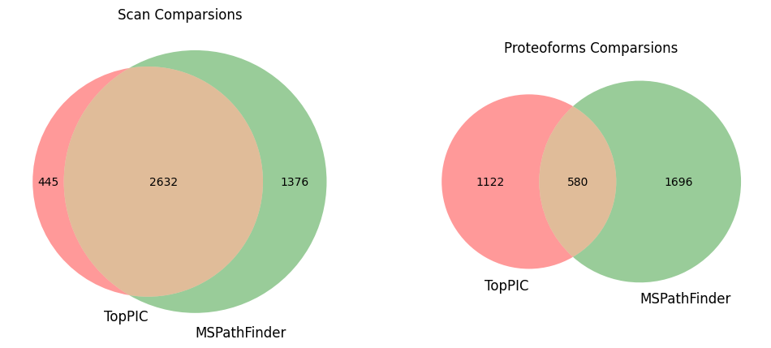

```python
from matplotlib_venn import venn2

fig, axes = plt.subplots(1, 2, figsize=(12, 6))

set1 = set(prsm_df_TopPIC["Scan(s)"])
set2 = set(prsm_df_MSP["Scan"])
axes[0].set_title("Scan Comparsions")
venn2([set1, set2], ('TopPIC', 'MSPathFinder'), ax=axes[0])

set1 = set(prsm_df_TopPIC["Proteoform"].unique())
set2 = set(prsm_df_MSP["Proteoform"].unique())
axes[1].set_title("Proteoforms Comparsions")
venn2([set1, set2], ('TopPIC', 'MSPathFinder'), ax=axes[1])
plt.show()
```

We can then take a look at the distributions of proteoform mass between the two search results

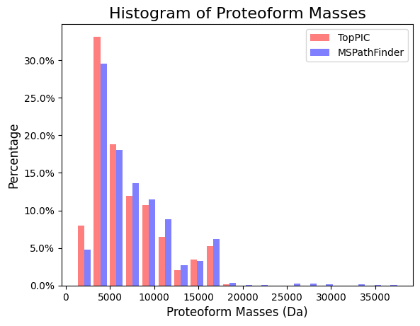

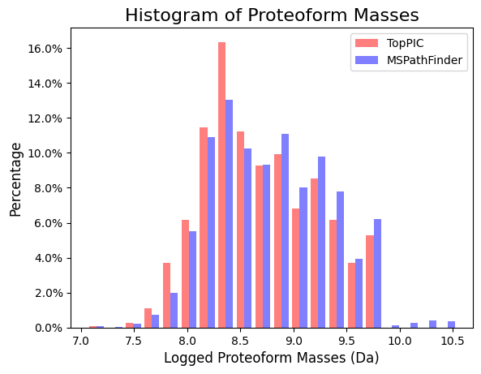

```python
from matplotlib.ticker import PercentFormatter

plt.hist([prsm_df_TopPIC["Proteoform mass"], prsm_df_MSP["Mass"]], weights=[np.ones(len(prsm_df_TopPIC)) / len(prsm_df_TopPIC), np.ones(len(prsm_df_MSP)) / len(prsm_df_MSP)], color=['r','b'], alpha=0.5, bins=20)
plt.gca().yaxis.set_major_formatter(PercentFormatter(1))
plt.legend(["TopPIC","MSPathFinder"])
plt.title("Histogram of Proteoform Masses", fontsize=16)
plt.xlabel("Proteoform Masses (Da)", fontsize=12)
plt.ylabel("Percentage", fontsize=12)
plt.show()

plt.hist([np.log(prsm_df_TopPIC["Proteoform mass"]), np.log(prsm_df_MSP["Mass"])], weights=[np.ones(len(prsm_df_TopPIC)) / len(prsm_df_TopPIC), np.ones(len(prsm_df_MSP)) / len(prsm_df_MSP)], color=['r','b'], alpha=0.5, bins=20)
plt.gca().yaxis.set_major_formatter(PercentFormatter(1))
plt.legend(["TopPIC","MSPathFinder"])
plt.title("Histogram of Proteoform Masses", fontsize=16)
plt.xlabel("Logged Proteoform Masses (Da)", fontsize=12)
plt.ylabel("Percentage", fontsize=12)
```

Looking at the unlogged distribution, we can observe that both are skewed to the right, meaning that we should probably take the log of the masses, which is already in place. Furthermore, in comparsion with MSPathFinder, more of TopPIC's proteoform masses in the lower weights (<5000 Da), and that we can indeed see a trend of TopPIc being able to detect more proteoforms with lower masses. Our next step would be to look at if the proteoform mass reflect well on the precursor masses. The general assumption is that it should, unless we are looking at very small proteoforms (<1000 Da)

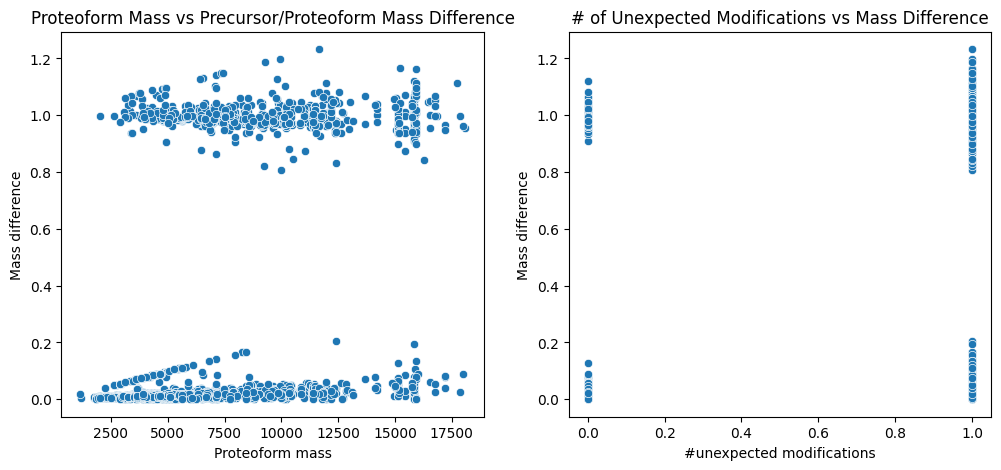

```python
import seaborn as sns

fig, axes = plt.subplots(1, 2, figsize=(12, 5))

prsm_df_TopPIC["Mass difference"] = np.abs(prsm_df_TopPIC["Precursor mass"] - prsm_df_TopPIC["Proteoform mass"])
sns.scatterplot(data=prsm_df_TopPIC, x="Proteoform mass", y="Mass difference", ax=axes[0])
axes[0].set_title("Proteoform Mass vs Precursor/Proteoform Mass Difference")

sns.scatterplot(data=prsm_df_TopPIC, x="#unexpected modifications", y="Mass difference", ax=axes[1])
axes[1].set_title("# of Unexpected Modifications vs Mass Difference")
```